# Practical 3

In this third practical, we expand the retail sales dataset of Practical 2 to include multiple products. Data for Product 1 (from Practical 2) and an additional 9 products are given in two forms: $sales10.csv$ and $sales10adjusted.csv$, with the same format. As the name indicates, sales volumes in the latter file have been adjusted for trend and seasonality *(removing growth and cyclical patterns).*

```r
#data

sales10 <- read.csv(here::here("sales_10.csv"))
sales10adj <- read.csv(here::here("sales_10_adjusted.csv"))
```

## Exercise A

> Explain the challenges involved when analysing the risk of stock-out across several products. What is the danger of considering each series independently?

The aplication of an independently analysis (EVT) could cause a loss of information and therefore a lack of preparation in face of a risky event. For example, the analysis of stock out from 3 products independently are not consider risky, nevertheless, the stock out of the 3 together could be consider as a very high risky event due to the high probability of loosing a customer.

**MEVT has as a main objective to find the probabilities that extreme events happen together.**

The main problem would be given by the fact that the different products may not be independent even if we consider them to be, it can be seen if one of them has an extreme value in the demand and so does another one, every time at the same date. This can happen as the products may be related, as for example could be bread and butter, meaning that if there is an increase in the demand of one product, so there will be in the demand for the other one. Another possibility is the fact that, especially for extreme values, so an abrupt change in the demand, could be determined by external factors, such as a natural disaster, that would make the demand for all sort of products increase from one day to the other. Indeed, it could be a problem, as by analysing the stock-outs, which are extreme values, independently one from the other, we could miss some important relationship that are between them and not being able to assess the risk in the best way possible.

## Exercise B

> Propose one graphical and one numerical method of detecting dependence of extreme values of the demand across several products. Apply your chosen methods to the adjusted sales data and identify groups of related products (if any exist).

[output not shown]

### Graphical method

First, let’s create a plot with all the products’ demands distibutions.

#### All the products distribution

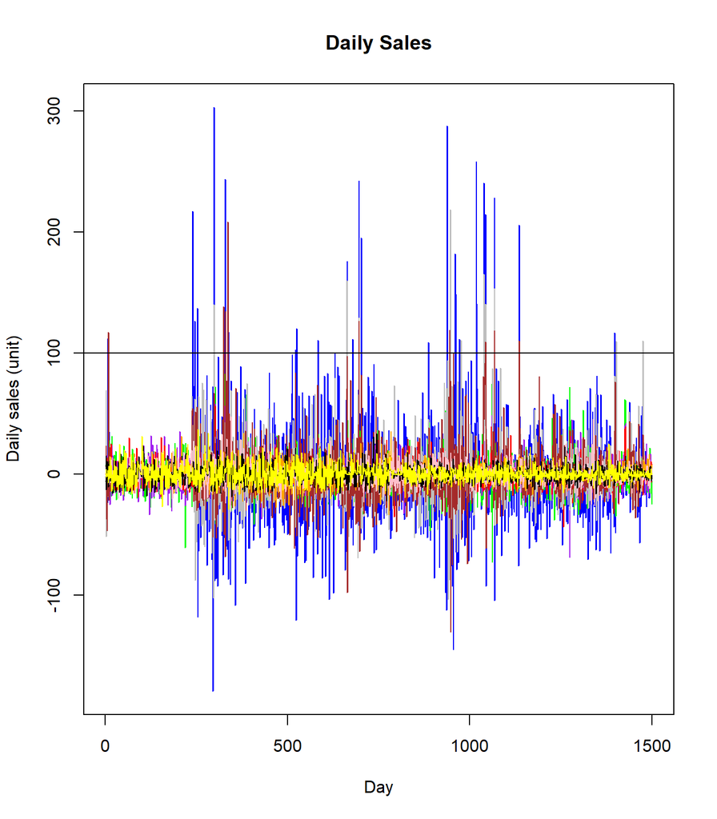

```
## integer(0)
```

In order to determine the threshold for the extreme values, we will take the 98% quantile of the distribution of the sales of each product, as we could find very different distributions and taking only one threshold overall would not give us any important information.

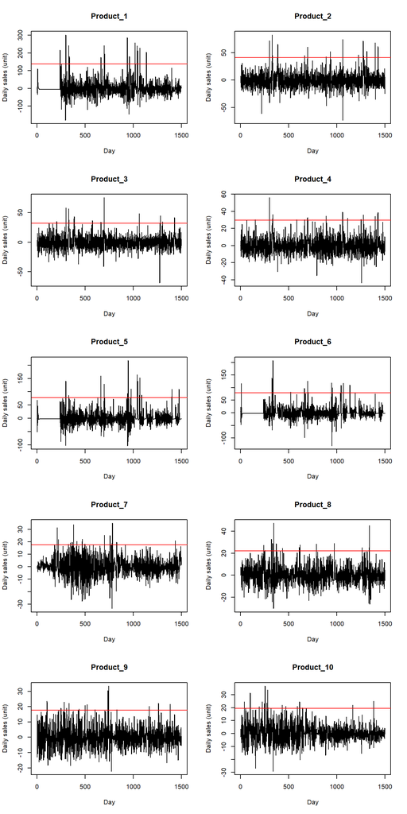

As we can see, we have some observations in each product that are above the line. We are particularly interested in seeing if there is a repetition in the observations that are above the lines that happen around the same time for different products.

#### Repitition Day

Now, we will determine the number of the observation in which we pass the line for each products and we try to see if there are some days that are close enough or repetead.

Check if there are any repetition above the lines that happen around the same time between the products

[output not shown]

We can see that especially for the dates of **products 2 and 3** we have some repetitions of the same values, also for products 8 and 7 it looks like there is some similitudes or closeness of the values.

#### Chi-plot

The other method we can use is to create the chi plot for all the couples of products to assess the distributions of their tails and see if there is any correlation.

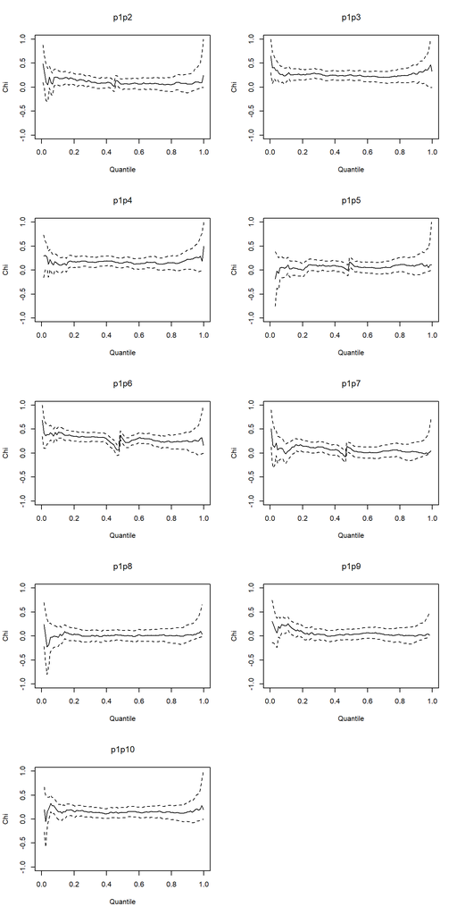

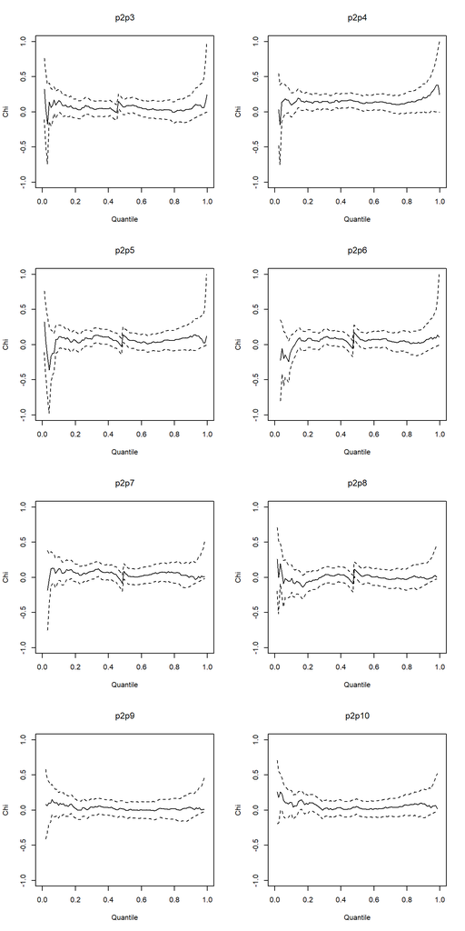

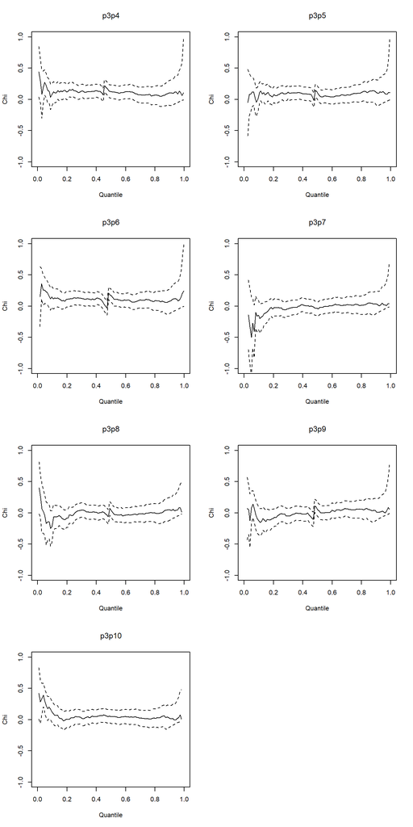

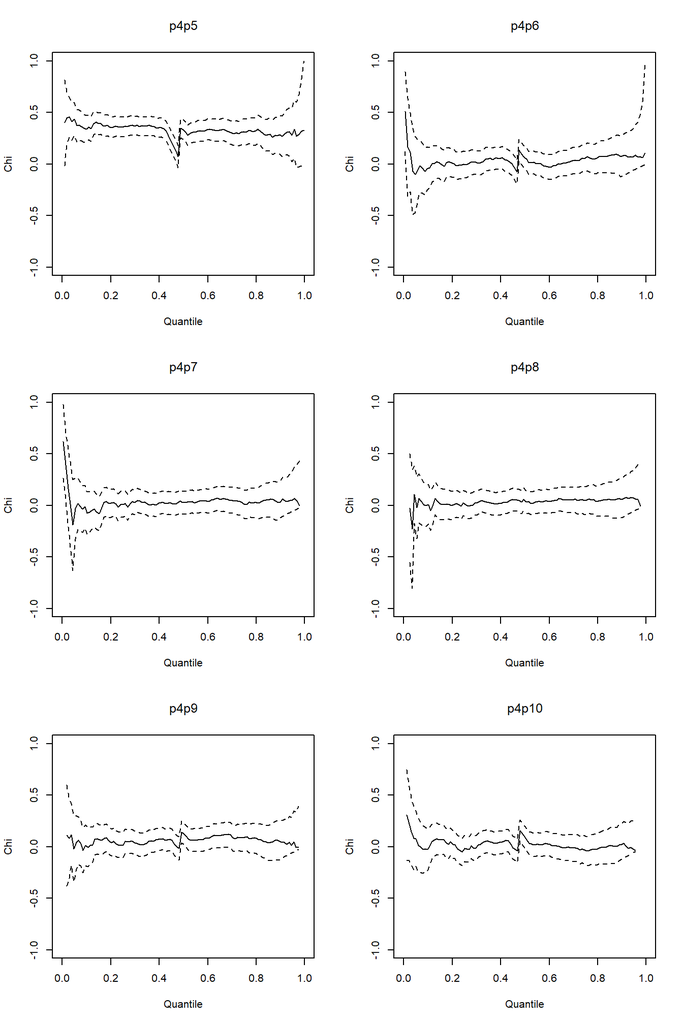

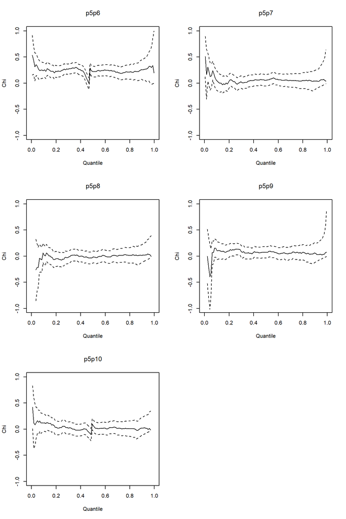

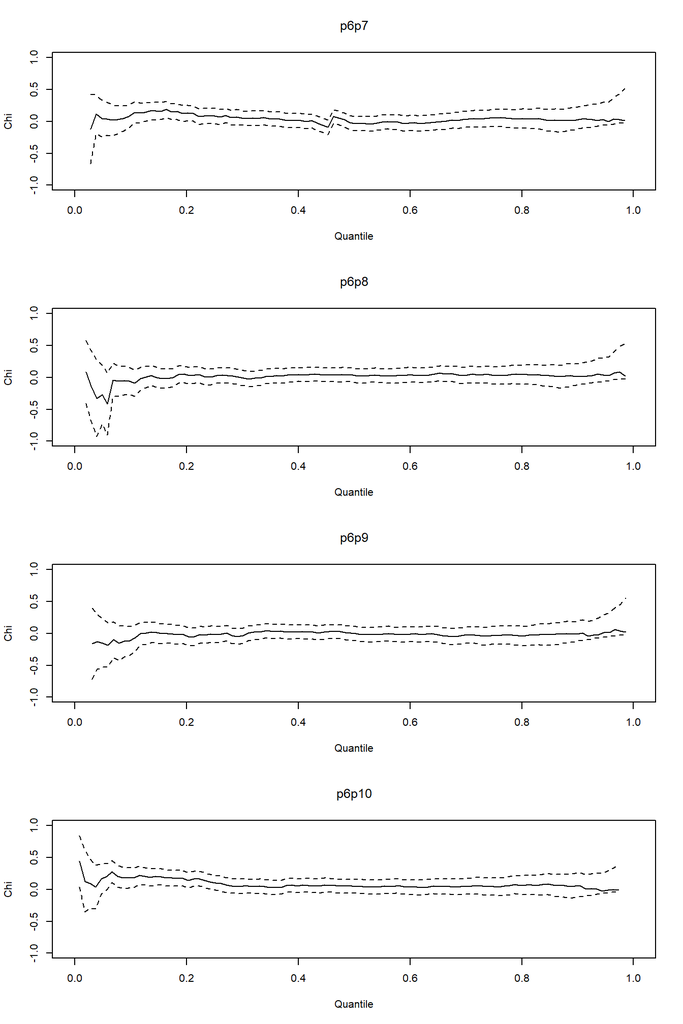

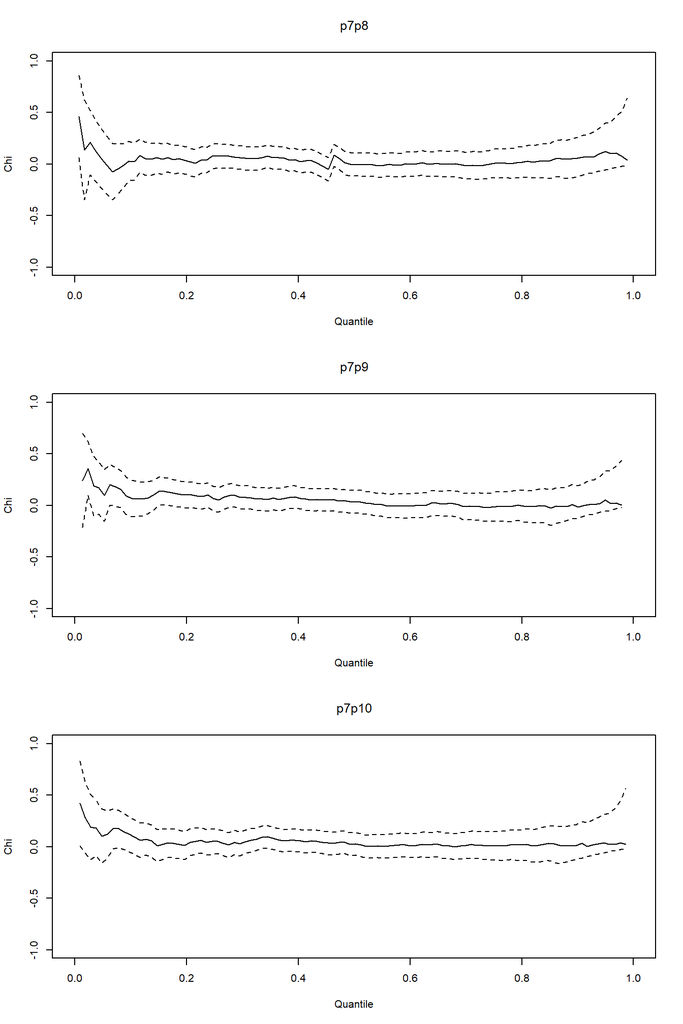

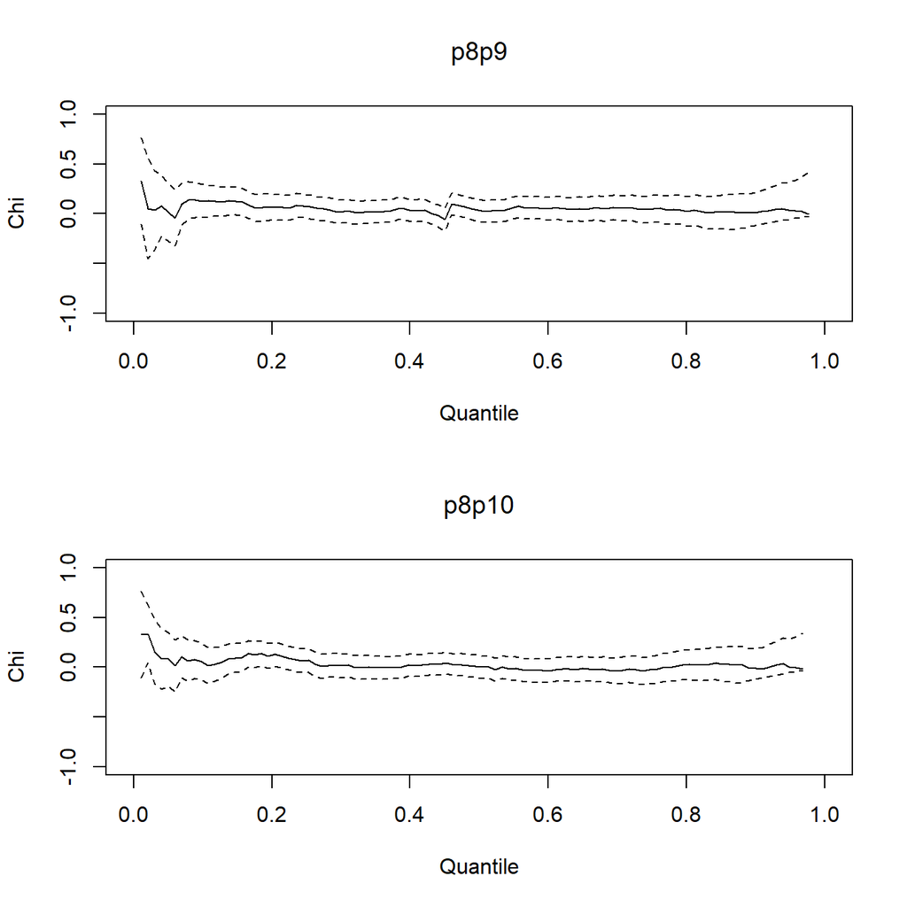

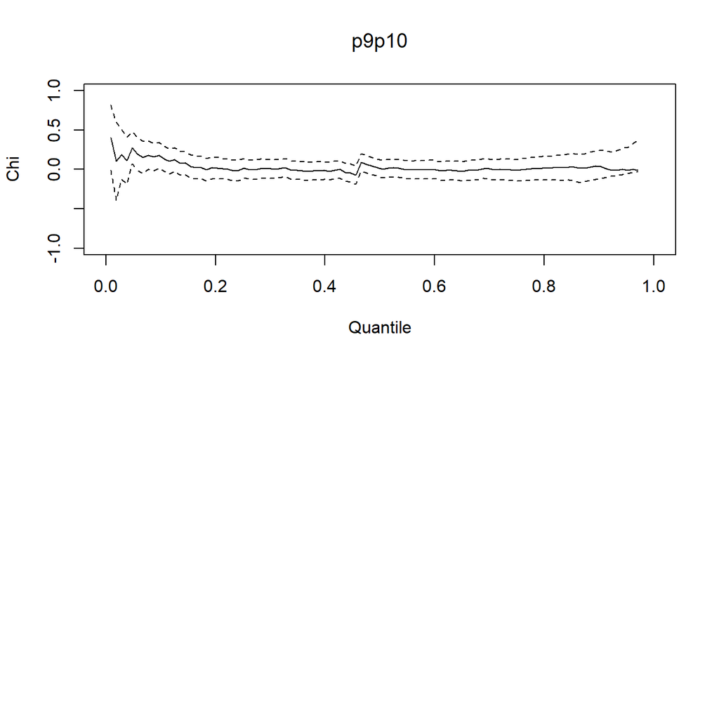

**Key takeaway**

### Matematical method

While for the mathematical method, we will construct a matrix containing the chi bar values for all the couples of products.

Chi bar Matrix

|  | p2 | p3 | p4 | p5 | p6 | p7 | p8 | p9 | p10 |
| --- | --- | --- | --- | --- | --- | --- | --- | --- | --- |
| p1 | 0.218 | 0.181 | 0.200 | 0.442 | 0.442 | 0.039 | 0.218 | 0.094 | -0.072 |
| p2 | 0.000 | 0.508 | 0.430 | 0.236 | 0.140 | 0.161 | 0.068 | 0.094 | 0.007 |
| p3 | 0.000 | 0.000 | 0.406 | 0.218 | 0.218 | 0.118 | 0.094 | 0.007 | 0.068 |
| p4 | 0.000 | 0.000 | 0.000 | 0.161 | 0.140 | 0.039 | 0.161 | 0.094 | -0.072 |
| p5 | 0.000 | 0.000 | 0.000 | 0.000 | 0.430 | 0.039 | 0.118 | 0.039 | -0.029 |
| p6 | 0.000 | 0.000 | 0.000 | 0.000 | 0.000 | -0.029 | -0.029 | 0.007 | -0.127 |
| p7 | 0.000 | 0.000 | 0.000 | 0.000 | 0.000 | 0.000 | 0.094 | 0.039 | 0.007 |
| p8 | 0.000 | 0.000 | 0.000 | 0.000 | 0.000 | 0.000 | 0.000 | 0.068 | 0.118 |
| p9 | 0.000 | 0.000 | 0.000 | 0.000 | 0.000 | 0.000 | 0.000 | 0.000 | 0.328 |

### Aggregation method

To investigate a possible clustering of the different products, we will create create a graph with the mean and variance for each product.

#### Distance: Mean and variance

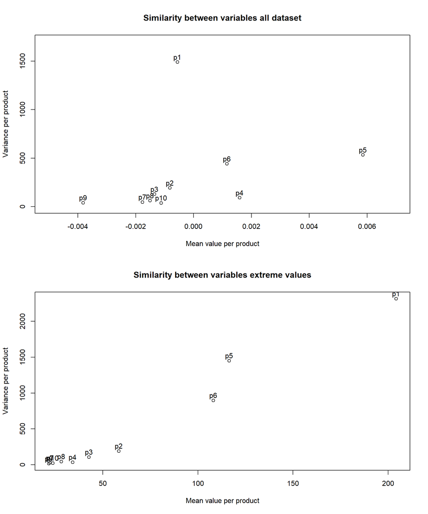

#### Defining k

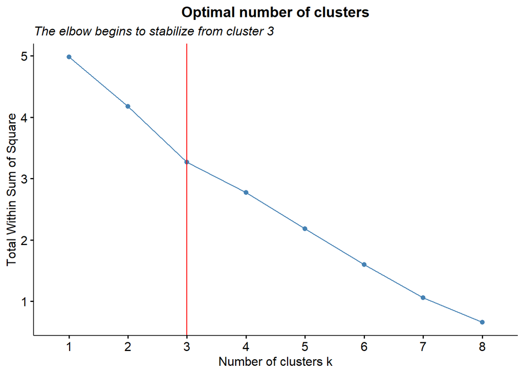

#### Cluster with distance: Kendall’s tau

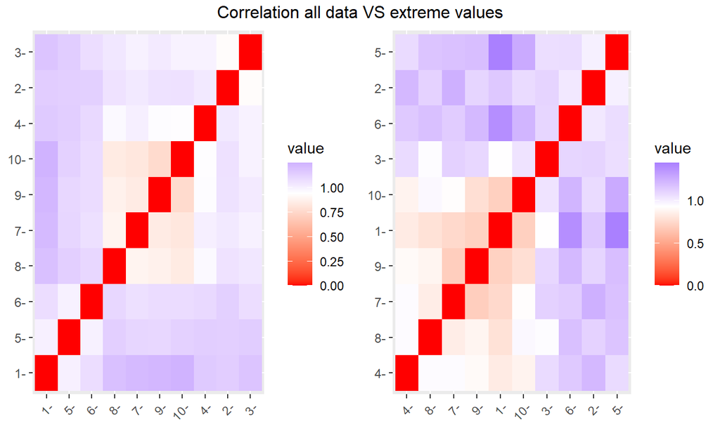

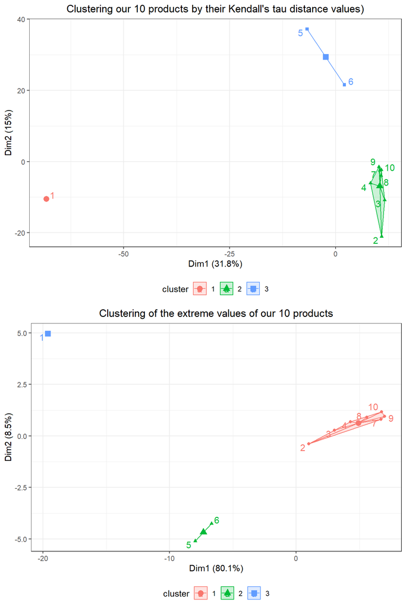

**Key takeaway** What is interesting to notice, is that the clustering are the same if we consider the whole distribution and only the most extreme values. Netherless, the correlation are stronger in the extreme values, thus we confirm that an independent analysis could potentialy lose important information.

In both cases, we can see that there is some similarity in some products, and some differences in others, especially product 1 appreas to be very different from the others, while products 9, 10 7, 8, 4, 3 and 2 appear very similar (the cluster in green). However, the number of clusters that should be used is not very clear, as the decrease of total within sum of sqaure is quite linear.

## Exercise C

> In view of your answer to (b), would you apply a Gaussian copula model to these data?

As well as the EVT the Gaussian model does not caputre all the information for the extreme values. Keeping this concept for multivariate extreme value theory we can see that in this case the corelation is higher, thus we cannot apply this model to fit the extreme value of the products’ distribution.

As we could find some depence in the distribution of the tails of our products’ demand, we believe that a gaussian distribution would not be optimal, as it is not able to consider the depences in the tails of the distribution.